# Chaudhary_Homework_6

## PROBLEM 2

2. The website https://www.theguardian.com/news/datablog/2012/nov/07/us-2012-election-county-results-download has county-level election results for the 2012 US Presidential election. Download the Excel file and then read that into R (in submitting your homework, you may assume that the file is already downloaded to the working directory). Please make the following maps: a The popular vote totals for Obama

```r
## Load excel into R
election <- read_excel("US_elect_county.xls", sheet = "OBAMA V ROMNEY ONLY", na="", col_names = TRUE, col_types = NULL)
```

[output not shown]

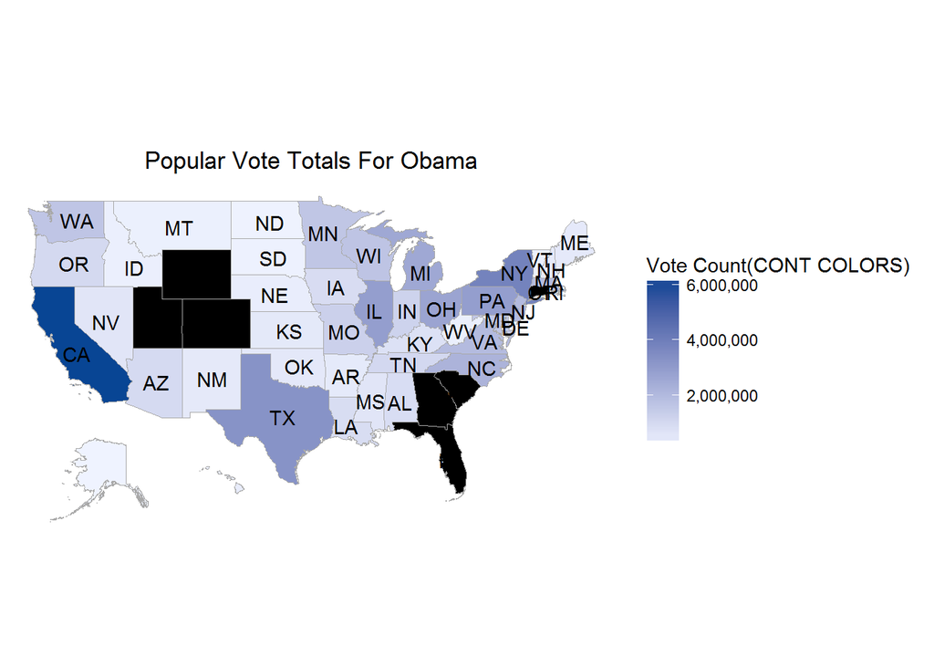

```r
names(election) <- make.names(names(election))

colnames(election) <- c("State.Postal", "State.Name", "FIPS", "Obama.vote", "X", "Romney.vote", "Y")

election_state <- filter(election, election$'FIPS' == "0")

election_state_Obama <- select(election_state, State.Name, Obama.vote)

election_state_Obama$State.Name <- str_to_lower(election_state_Obama$State.Name)

colnames(election_state_Obama) <- c("region", "value")

# Remove duplicate rows
election_state_Obama1 <- election_state_Obama[!duplicated(election_state_Obama[,c('region')]),]

# MAP WITH CONTINOUS COLORS
state_choropleth(election_state_Obama1,
                 title  = "Popular Vote Totals For Obama",
                 legend = "Vote Count(CONT COLORS)", num_colors = 1)
```

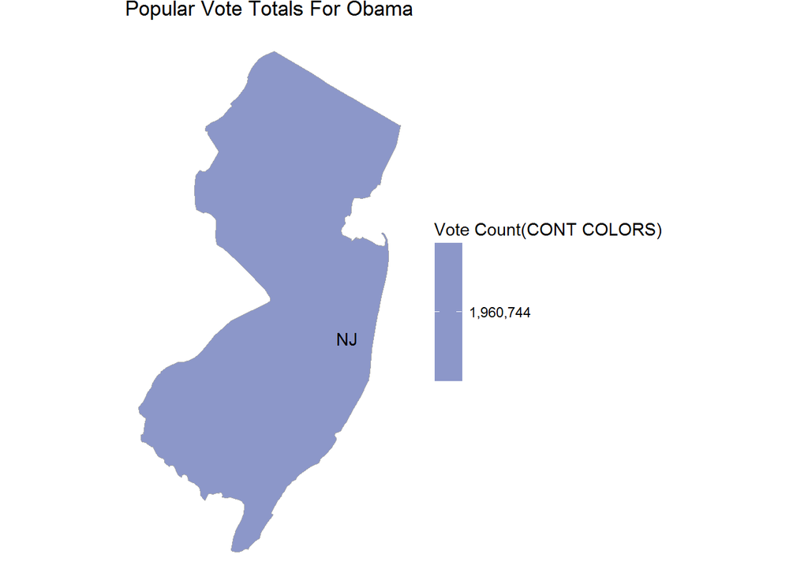

```r
# NJ MAP WITH CONTINOUS COLORS
state_choropleth(election_state_Obama1,
                 title  = "Popular Vote Totals For Obama",
                 legend = "Vote Count(CONT COLORS)", num_colors = 1, zoom = "new jersey" )
```

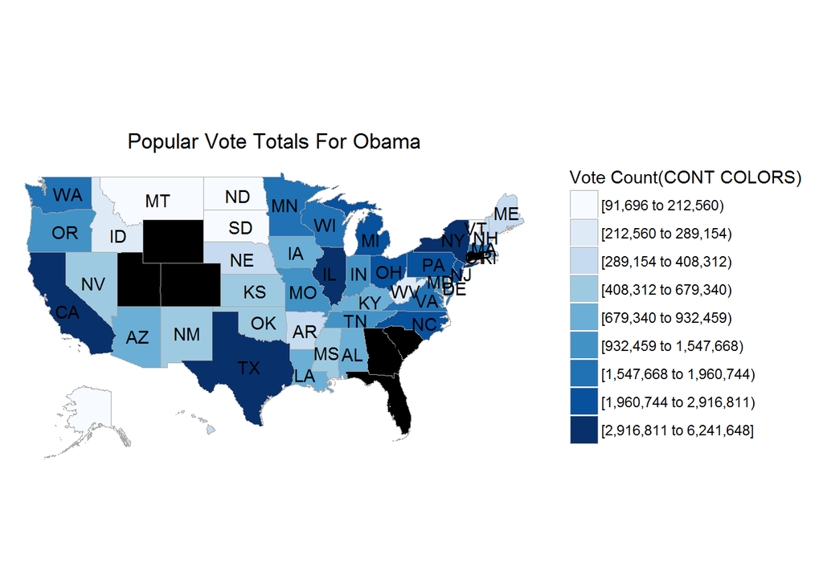

```r
# MAP WITH BINNED COLORS
state_choropleth(election_state_Obama1,
                 title  = "Popular Vote Totals For Obama",
                 legend = "Vote Count(CONT COLORS)", num_colors = 9)
```

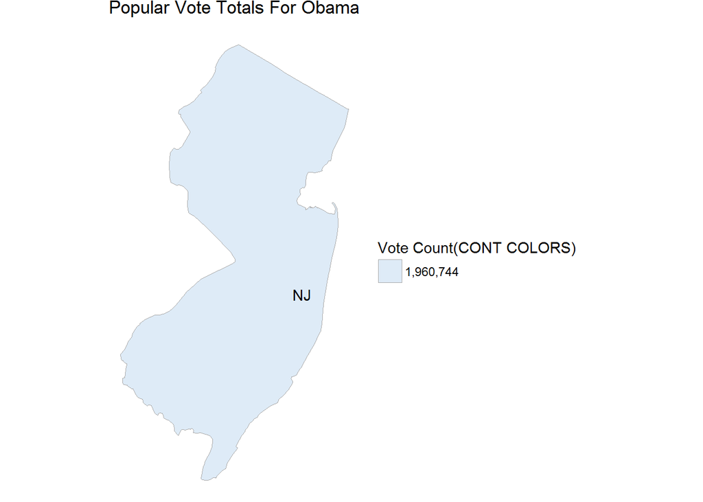

```r
# NJ MAP WITH BINNED COLORS
state_choropleth(election_state_Obama1,
                 title  = "Popular Vote Totals For Obama",
                 legend = "Vote Count(CONT COLORS)", num_colors = 9, zoom = "new jersey")
```

b The popular vote totals for Romney

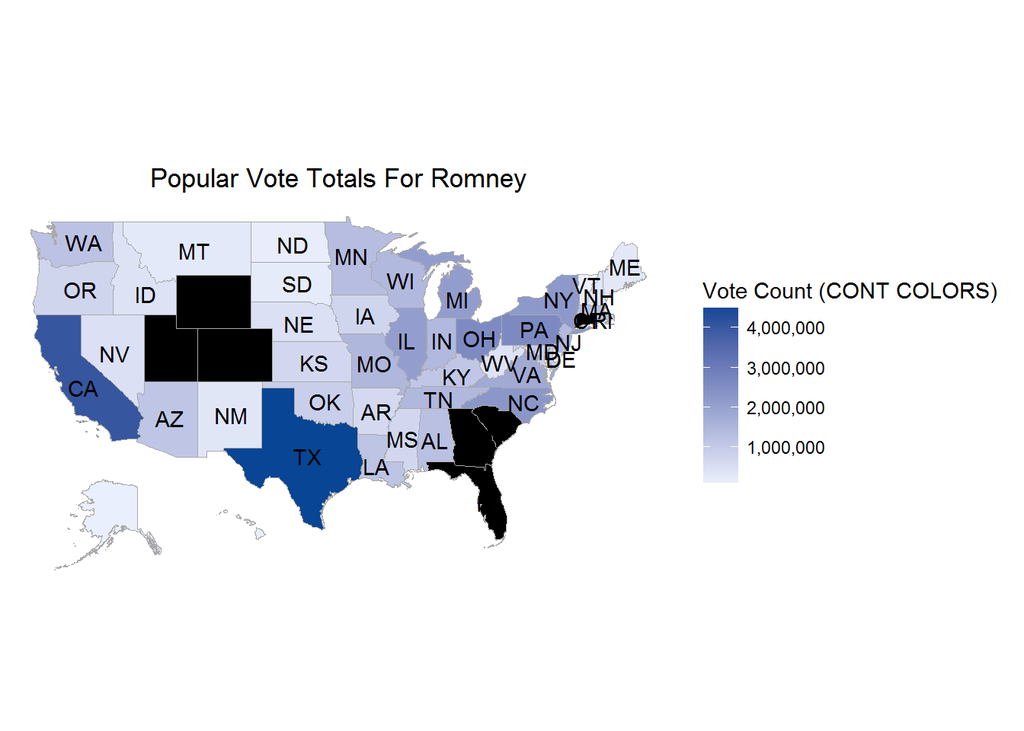

```r
election_state_Romney <- select(election_state, State.Name, Romney.vote)

election_state_Romney$State.Name <- str_to_lower(election_state_Romney$State.Name)

colnames(election_state_Romney) <- c("region", "value")

# Remove duplicate rows
election_state_Romney1 <- election_state_Romney[!duplicated(election_state_Romney[,c('region')]),]

# MAP WITH CONTINOUS COLORS
state_choropleth(election_state_Romney1,
                 title  = "Popular Vote Totals For Romney",
                 legend = "Vote Count (CONT COLORS)", num_colors = 1)
```

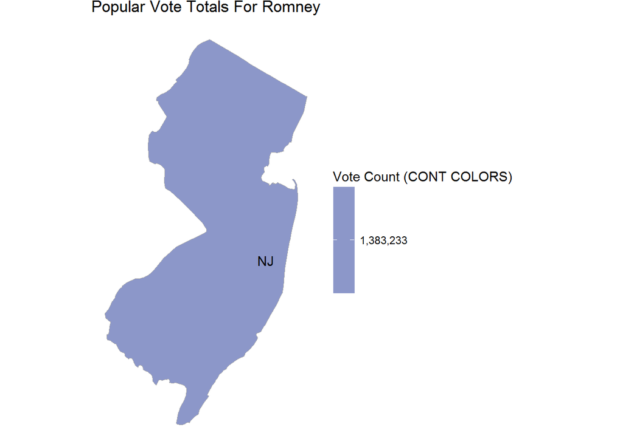

```r
# NJ MAP WITH CONTINOUS COLORS
state_choropleth(election_state_Romney1,
                 title  = "Popular Vote Totals For Romney",
                 legend = "Vote Count (CONT COLORS)", num_colors = 1, zoom = "new jersey")
```

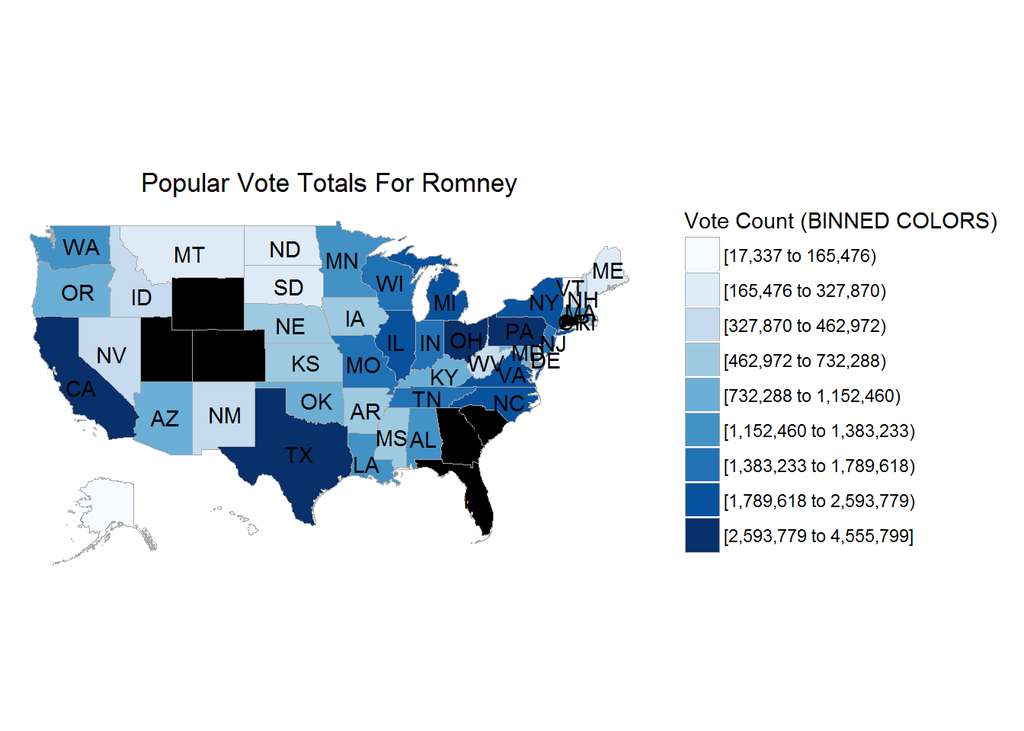

```r
# MAP WITH BINNED COLORS
state_choropleth(election_state_Romney1,
                 title  = "Popular Vote Totals For Romney",
                 legend = "Vote Count (BINNED COLORS)", num_colors = 9)
```

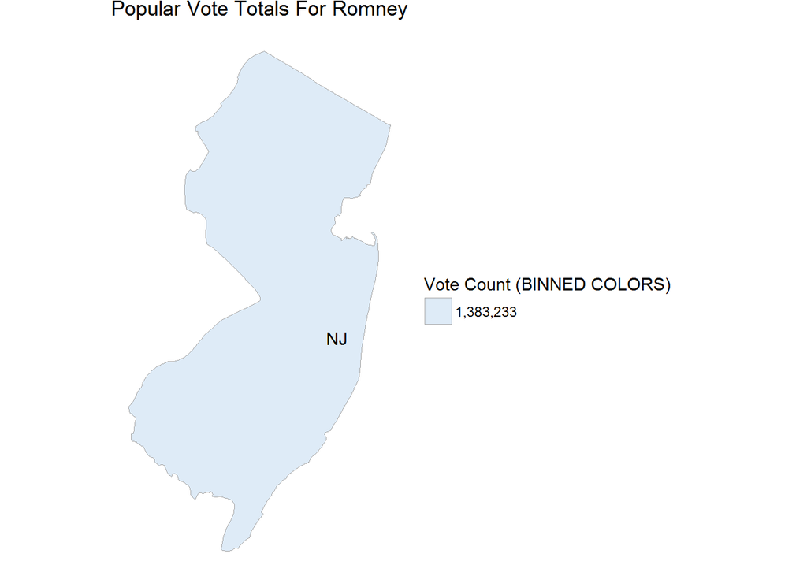

```r
# NJ MAP WITH BINNED COLORS
state_choropleth(election_state_Romney1,
                 title  = "Popular Vote Totals For Romney",
                 legend = "Vote Count (BINNED COLORS)", num_colors = 9, zoom = "new jersey")
```

c The percentage of the 2-candidate vote for Obama

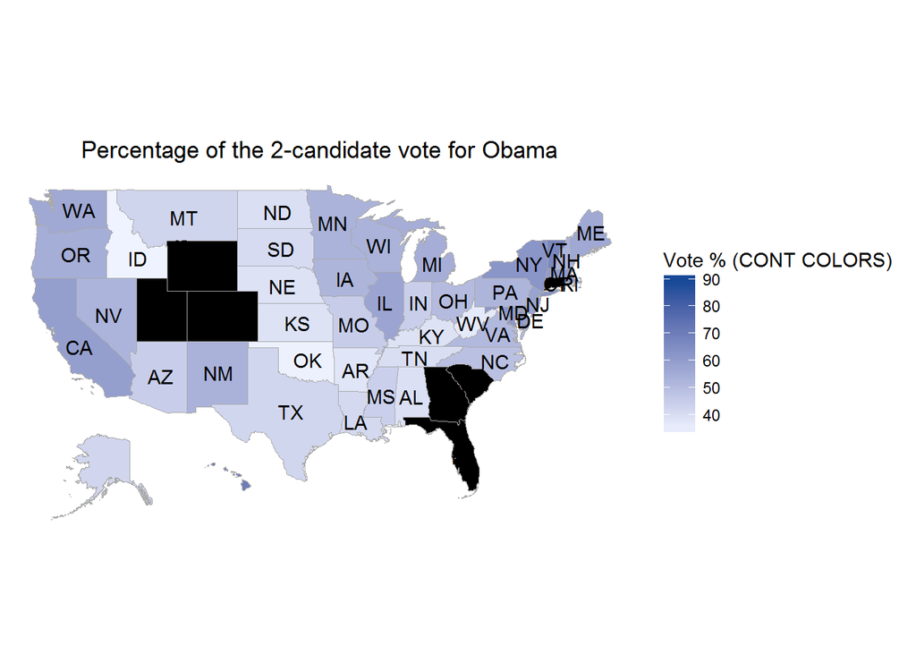

```r
election_state_Obamapercent <- select(election_state, State.Name, X)

election_state_Obamapercent$State.Name <- str_to_lower(election_state_Obamapercent$State.Name)

colnames(election_state_Obamapercent) <- c("region", "value")

# Remove duplicate rows
election_state_Obamapercent1 <- election_state_Obamapercent[!duplicated(election_state_Obamapercent[,c('region')]),]

# MAP WITH CONTINOUS COLORS
state_choropleth(election_state_Obamapercent1,
                 title  = "Percentage of the 2-candidate vote for Obama",
                 legend = "Vote % (CONT COLORS)", num_colors = 1)
```

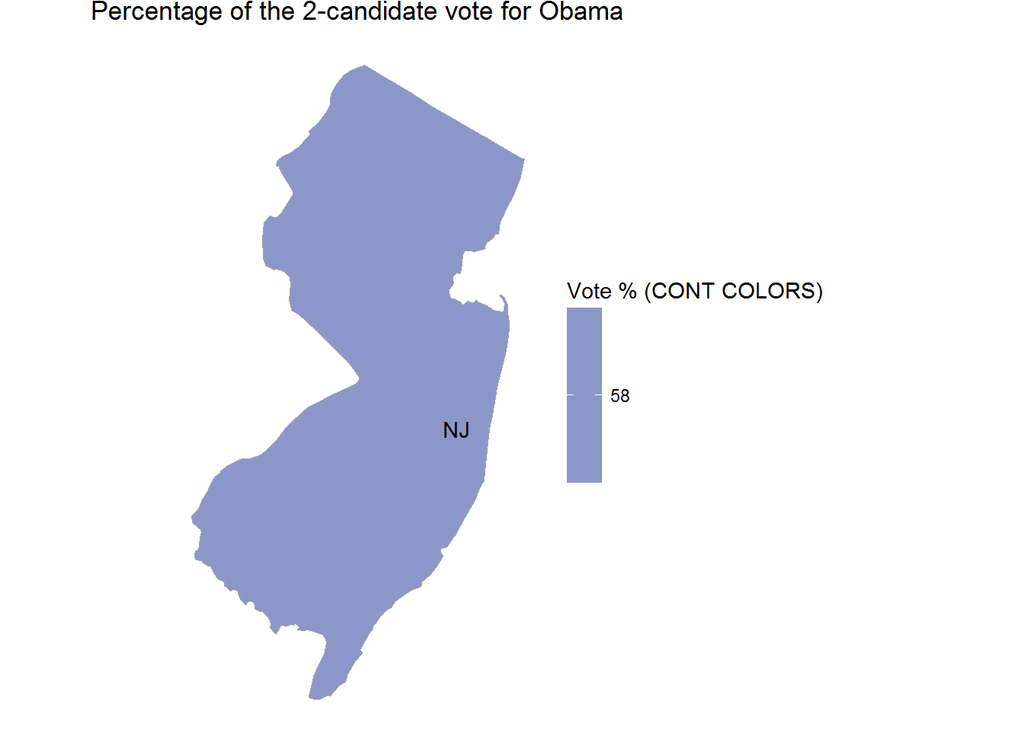

```r
# NJ MAP WITH CONTINOUS COLORS
state_choropleth(election_state_Obamapercent1,
                 title  = "Percentage of the 2-candidate vote for Obama",
                 legend = "Vote % (CONT COLORS)", num_colors = 1, zoom = "new jersey")
```

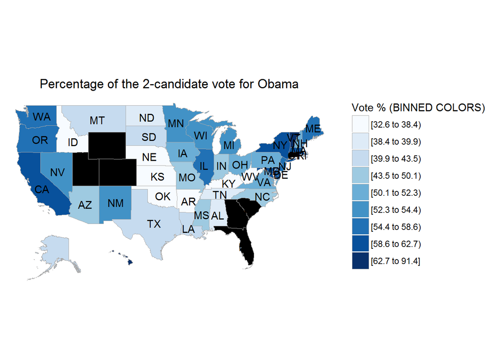

```r
# MAP WITH BINNED COLORS
state_choropleth(election_state_Obamapercent1,
                 title  = "Percentage of the 2-candidate vote for Obama",
                 legend = "Vote % (BINNED COLORS)", num_colors = 9)
```

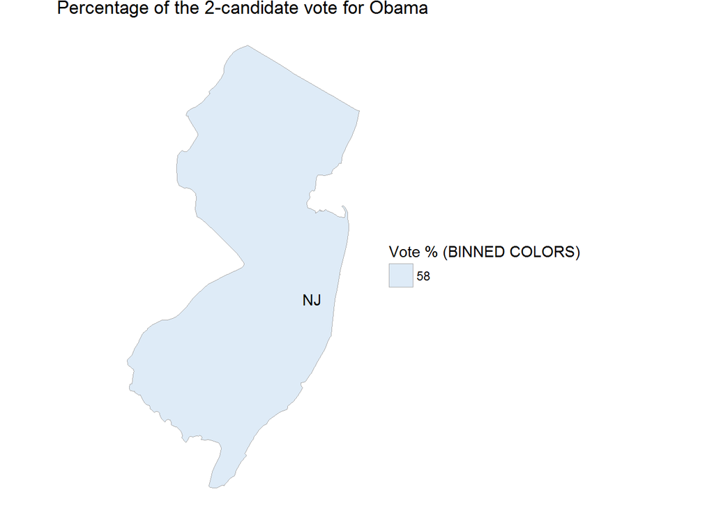

```r
# NJ MAP WITH BINNED COLORS
state_choropleth(election_state_Obamapercent1,
                 title  = "Percentage of the 2-candidate vote for Obama",
                 legend = "Vote % (BINNED COLORS)", num_colors = 9, zoom = "new jersey")
```

## Problem 3

3. The weather history on October 17 for the closest (small) airport to Piscataway can be found at https://www.wunderground.com/history/airport/KSMQ/2016/10/17/DailyHistory.html? req_city=Piscataway&req_state=NJ&req_statename=New+Jersey&reqdb.zip=08854&reqdb.magic=1&reqdb.wmo=99999 Download (and clean) the table at the bottom of the page, using html_node(“#obsTable”), not html_node(“table”). Please plot the time of day against temperature and dew point for the day (I suggest using a line and points for each, and separate colors for the temp/dew point).

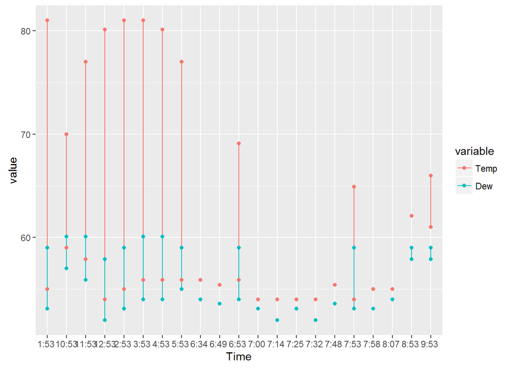

```r
url_weather <- "https://www.wunderground.com/history/airport/KSMQ/2016/10/17/DailyHistory.html?req_city=Piscataway&req_state=NJ&req_statename=New+Jersey&reqdb.zip=08854&reqdb.magic=1&reqdb.wmo=99999"

hourly_weather <-
  url_weather %>%
  read_html() %>%
     html_nodes("#obsTable") %>%
       html_table(fill = TRUE)

hourly_weather <- data.frame(hourly_weather)

hourly_weather1 <- select(hourly_weather, Time..EDT., Temp., Dew.Point)


colnames(hourly_weather1) <- c("Time", "Temp", "Dew")

hourly_weather1$Time <- str_sub(hourly_weather1$Time, end = 5)
hourly_weather1$Temp <- as.double(str_sub(hourly_weather1$Temp, end = 4))
hourly_weather1$Dew <- as.double(str_sub(hourly_weather1$Dew, end = 4))

require(data.table)

test_data_long <- melt(hourly_weather1, id="Time")  # convert to long format

ggplot(data=test_data_long,
       aes(x=Time, y=value, colour=variable)) +
  geom_line() + geom_point()
```